# HR Analytics: Job Change of Data Scientists

Vallabh Sawant, Harshal Utekar, Vaibhavi Mukadam

### Importing the data:

```r
job <- read.csv("C:\\Users\\valla\\OneDrive\\Desktop\\Vallabh_Rutgers\\DADM\\Project\\aug_train.csv")
library(ggplot2)
library(gridExtra)
library(DAAG)
```

### Exploratory Data Analysis

Structure of Data:

```r
str(job)
```

```
## 'data.frame':    19158 obs. of  14 variables:
##  $ enrollee_id           : int  8949 29725 11561 33241 666 21651 28806 402 27107 699 ...
##  $ city                  : chr  "city_103" "city_40" "city_21" "city_115" ...
##  $ city_development_index: num  0.92 0.776 0.624 0.789 0.767 0.764 0.92 0.762 0.92 0.92 ...
##  $ gender                : chr  "Male" "Male" NA NA ...
##  $ relevent_experience   : chr  "Has relevent experience" "No relevent experience" "No relevent experience" "No relevent experience" ...
##  $ enrolled_university   : chr  "no_enrollment" "no_enrollment" "Full time course" NA ...
##  $ education_level       : chr  "Graduate" "Graduate" "Graduate" "Graduate" ...
##  $ major_discipline      : chr  "STEM" "STEM" "STEM" "Business Degree" ...
##  $ experience            : chr  ">20" "15" "5" "<1" ...
##  $ company_size          : chr  NA "50-99" NA NA ...
##  $ company_type          : chr  NA "Pvt Ltd" NA "Pvt Ltd" ...
##  $ last_new_job          : chr  "1" ">4" "never" "never" ...
##  $ training_hours        : int  36 47 83 52 8 24 24 18 46 123 ...
##  $ target                : int  1 0 0 1 0 1 0 1 1 0 ...
```

### Checking for NA’s to avoid Null Issues.

```r
table(is.na(job))
```

```
##
##  FALSE   TRUE
## 247479  20733
```

```r
job <- na.omit(job)
table(is.na(job))
```

```
##
##  FALSE
## 125370
```

### Modifying the variables:

```r
job$experience <- gsub('>20','21',job$experience)
job$experience <- gsub('<1','0',job$experience)
job$last_new_job <- gsub('>4','5',job$last_new_job)
job$last_new_job <- gsub('never','0',job$last_new_job)
job$last_new_job <- as.integer(job$last_new_job)
job$experience <- as.integer(job$experience)
```

### Converting categorical variables into factors:

```r
job$gender <- factor(job$gender,levels = c("Male","Female","Other"),labels = c("Male","Female","Other"))
job$relevent_experience <- factor(job$relevent_experience,levels = c("No relevent experience","Has relevent experience"),labels = c("No experience","Has Experience"))
job$enrolled_university <- factor(job$enrolled_university,levels = c("no_enrollment","Part time course","Full time course"),labels = c("Not enrolled","Part time","Full time"))
job$education_level <- factor(job$education_level,levels = c("Graduate","Masters","Phd"),labels = c("Graduate","Masters","PhD"))
job$major_discipline <- factor(job$major_discipline,levels = c("Arts","Business Degree","Humanities","STEM","Other","No Major"),labels = c("Arts","Business Degree","Humanities","STEM","Other","No Major"))
job$company_size <- factor(job$company_size,levels = c("<10"," 10  - 49","50-99","100-500","500-999","1000-4999","5000-9999","10000+"),labels = c("<10","10-49","50-99","100-500","500-999","1000-4999","5000-9999","10000+"))
job$company_type <- factor(job$company_type,levels = c("Early Stage Startup","Funded Startup","NGO","Public Sector","Pvt Ltd","Other"),labels = c("Early startup","Funded startup","NGO","Public","Private","Other"))
job$target <- factor(job$target,levels = c(0,1),labels = c("Not looking to switch","Looking for switch"))
```

### Final Structure of Dataset:

```r
str(job)
```

```
## 'data.frame':    8955 obs. of  14 variables:
##  $ enrollee_id           : int  29725 666 402 27107 23853 25619 6588 31972 19061 7041 ...
##  $ city                  : chr  "city_40" "city_162" "city_46" "city_103" ...
##  $ city_development_index: num  0.776 0.767 0.762 0.92 0.92 0.913 0.926 0.843 0.926 0.776 ...
##  $ gender                : Factor w/ 3 levels "Male","Female",..: 1 1 1 1 1 1 1 1 1 1 ...
##  $ relevent_experience   : Factor w/ 2 levels "No experience",..: 1 2 2 2 2 2 2 2 2 2 ...
##  $ enrolled_university   : Factor w/ 3 levels "Not enrolled",..: 1 1 1 1 1 1 1 1 1 1 ...
##  $ education_level       : Factor w/ 3 levels "Graduate","Masters",..: 1 2 1 1 1 1 1 2 2 1 ...
##  $ major_discipline      : Factor w/ 6 levels "Arts","Business Degree",..: 4 4 4 4 4 4 4 4 4 3 ...
##  $ experience            : int  15 21 13 7 5 21 16 11 11 0 ...
##  $ company_size          : Factor w/ 8 levels "<10","10-49",..: 3 3 1 3 7 6 NA 4 4 6 ...
##  $ company_type          : Factor w/ 6 levels "Early startup",..: 5 2 5 5 5 5 5 5 5 5 ...
##  $ last_new_job          : int  5 4 5 1 1 3 5 1 2 1 ...
##  $ training_hours        : int  47 8 18 46 108 23 18 68 50 65 ...
##  $ target                : Factor w/ 2 levels "Not looking to switch",..: 1 1 2 2 1 1 1 1 1 1 ...
##  - attr(*, "na.action")= 'omit' Named int [1:10203] 1 3 4 6 7 10 11 14 15 17 ...
##   ..- attr(*, "names")= chr [1:10203] "1" "3" "4" "6" ...
```

### Basic Summary of the whole Data:

```r
summary(job)
```

```
##   enrollee_id        city           city_development_index    gender
##  Min.   :    2   Length:8955        Min.   :0.4480         Male  :8073
##  1st Qu.: 8150   Class :character   1st Qu.:0.7940         Female: 804
##  Median :16924   Mode  :character   Median :0.9100         Other :  78
##  Mean   :16870                      Mean   :0.8446
##  3rd Qu.:25902                      3rd Qu.:0.9200
##  Max.   :33380                      Max.   :0.9490
##
##      relevent_experience   enrolled_university education_level
##  No experience :1104     Not enrolled:7594     Graduate:6252
##  Has Experience:7851     Part time   : 529     Masters :2449
##                          Full time   : 832     PhD     : 254
##
##
##
##
##         major_discipline   experience       company_size          company_type
##  Arts           : 129    Min.   : 0.00   50-99    :1986   Early startup : 385
##  Business Degree: 170    1st Qu.: 6.00   100-500  :1814   Funded startup: 784
##  Humanities     : 378    Median :10.00   10000+   :1449   NGO           : 356
##  STEM           :7989    Mean   :11.64   1000-4999: 930   Public        : 564
##  Other          : 177    3rd Qu.:18.00   <10      : 840   Private       :6794
##  No Major       : 112    Max.   :21.00   (Other)  : 985   Other         :  72
##                                          NA's     : 951
##   last_new_job   training_hours                     target
##  Min.   :0.000   Min.   :  1.00   Not looking to switch:7472
##  1st Qu.:1.000   1st Qu.: 23.00   Looking for switch   :1483
##  Median :2.000   Median : 47.00
##  Mean   :2.348   Mean   : 65.07
##  3rd Qu.:4.000   3rd Qu.: 88.00
##  Max.   :5.000   Max.   :336.00
##
```

### We can eliminate the columns enrollee_id and city as they do not play a key role in either exploring the data visually or act as an independent variable.

```r
job <- subset(job,select = -c(1:2))
str(job)
```

```
## 'data.frame':    8955 obs. of  12 variables:
##  $ city_development_index: num  0.776 0.767 0.762 0.92 0.92 0.913 0.926 0.843 0.926 0.776 ...
##  $ gender                : Factor w/ 3 levels "Male","Female",..: 1 1 1 1 1 1 1 1 1 1 ...
##  $ relevent_experience   : Factor w/ 2 levels "No experience",..: 1 2 2 2 2 2 2 2 2 2 ...
##  $ enrolled_university   : Factor w/ 3 levels "Not enrolled",..: 1 1 1 1 1 1 1 1 1 1 ...
##  $ education_level       : Factor w/ 3 levels "Graduate","Masters",..: 1 2 1 1 1 1 1 2 2 1 ...
##  $ major_discipline      : Factor w/ 6 levels "Arts","Business Degree",..: 4 4 4 4 4 4 4 4 4 3 ...
##  $ experience            : int  15 21 13 7 5 21 16 11 11 0 ...
##  $ company_size          : Factor w/ 8 levels "<10","10-49",..: 3 3 1 3 7 6 NA 4 4 6 ...
##  $ company_type          : Factor w/ 6 levels "Early startup",..: 5 2 5 5 5 5 5 5 5 5 ...
##  $ last_new_job          : int  5 4 5 1 1 3 5 1 2 1 ...
##  $ training_hours        : int  47 8 18 46 108 23 18 68 50 65 ...
##  $ target                : Factor w/ 2 levels "Not looking to switch",..: 1 1 2 2 1 1 1 1 1 1 ...
```

### Summary of the data:

```r
summary(job)
```

```
##  city_development_index    gender         relevent_experience
##  Min.   :0.4480         Male  :8073   No experience :1104
##  1st Qu.:0.7940         Female: 804   Has Experience:7851
##  Median :0.9100         Other :  78
##  Mean   :0.8446
##  3rd Qu.:0.9200
##  Max.   :0.9490
##
##    enrolled_university education_level        major_discipline   experience
##  Not enrolled:7594     Graduate:6252   Arts           : 129    Min.   : 0.00
##  Part time   : 529     Masters :2449   Business Degree: 170    1st Qu.: 6.00
##  Full time   : 832     PhD     : 254   Humanities     : 378    Median :10.00
##                                        STEM           :7989    Mean   :11.64
##                                        Other          : 177    3rd Qu.:18.00
##                                        No Major       : 112    Max.   :21.00
##
##     company_size          company_type   last_new_job   training_hours
##  50-99    :1986   Early startup : 385   Min.   :0.000   Min.   :  1.00
##  100-500  :1814   Funded startup: 784   1st Qu.:1.000   1st Qu.: 23.00
##  10000+   :1449   NGO           : 356   Median :2.000   Median : 47.00
##  1000-4999: 930   Public        : 564   Mean   :2.348   Mean   : 65.07
##  <10      : 840   Private       :6794   3rd Qu.:4.000   3rd Qu.: 88.00
##  (Other)  : 985   Other         :  72   Max.   :5.000   Max.   :336.00
##  NA's     : 951
##                    target
##  Not looking to switch:7472
##  Looking for switch   :1483
##
##
##
##
##
```

### Outlier Detection and Removal

###Based on the data available, we have 4 independent variables that are numeric: ### 1. city_development_index ### 2. experience ### 3. last_new_job ### 4. training_hours

### Let’s put boxplots and QQ-plots to identify the no. of outliers for each of the variables.

### City_development_index

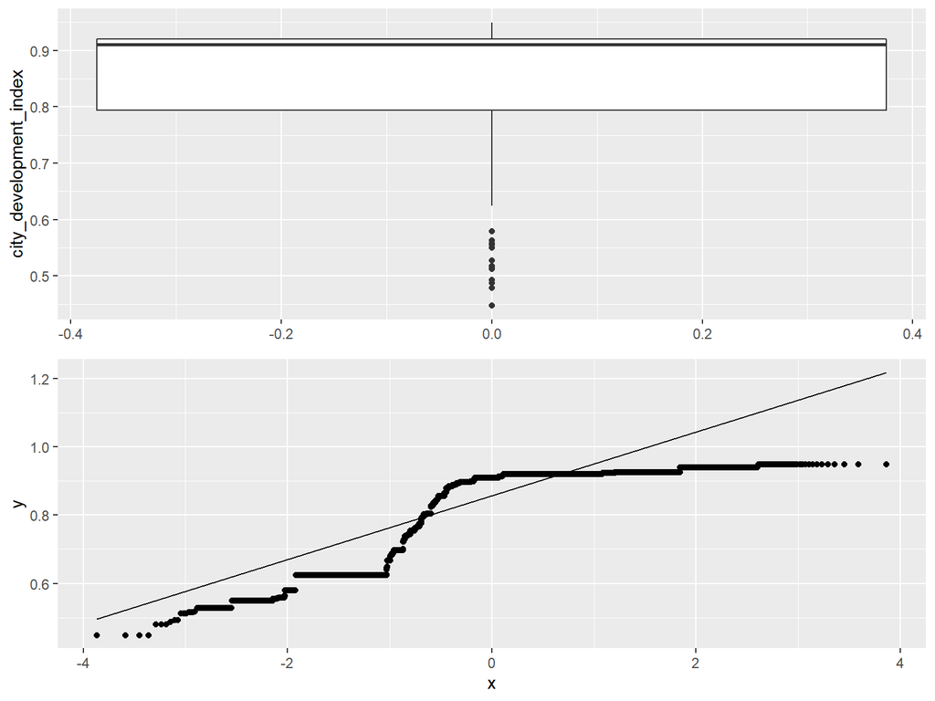

```r
c1 <- ggplot(job,aes(y=city_development_index))+geom_boxplot()
c2 <- ggplot(job,aes(sample=city_development_index))+geom_qq()+geom_qq_line()
grid.arrange(c1,c2)
```

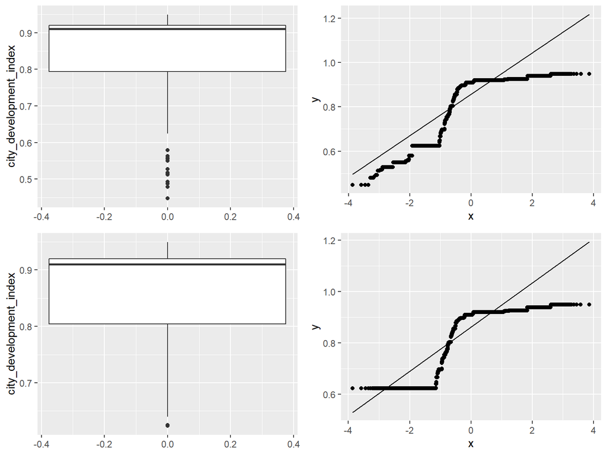

```r
o1 <- boxplot(job$city_development_index,plot=F)$out
job <- job[-which(job$city_development_index %in% o1),]
c3 <- ggplot(job,aes(y=city_development_index))+geom_boxplot()
c4 <- ggplot(job,aes(sample=city_development_index))+geom_qq()+geom_qq_line()
grid.arrange(c1,c2,c3,c4,nrow=2,ncol=2)
```

### Experience

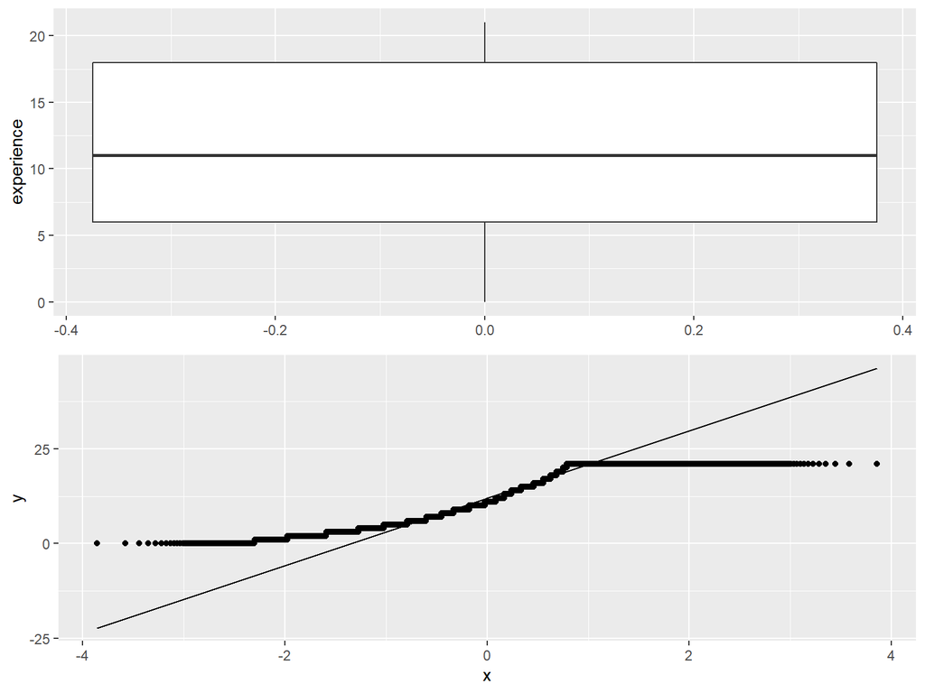

```r
e1 <- ggplot(job,aes(y=experience))+geom_boxplot()
e2 <- ggplot(job,aes(sample=experience))+geom_qq()+geom_qq_line()
grid.arrange(e1,e2)
```

### Last_New_Job

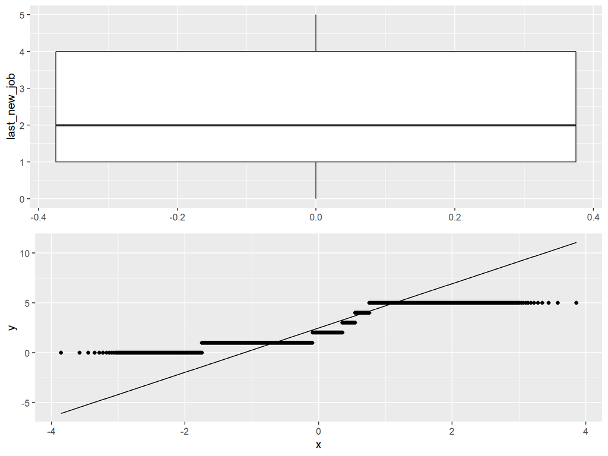

```r
l1 <- ggplot(job,aes(y=last_new_job))+geom_boxplot()
l2 <- ggplot(job,aes(sample=last_new_job))+geom_qq()+geom_qq_line()
grid.arrange(l1,l2)
```

### Training_Hours

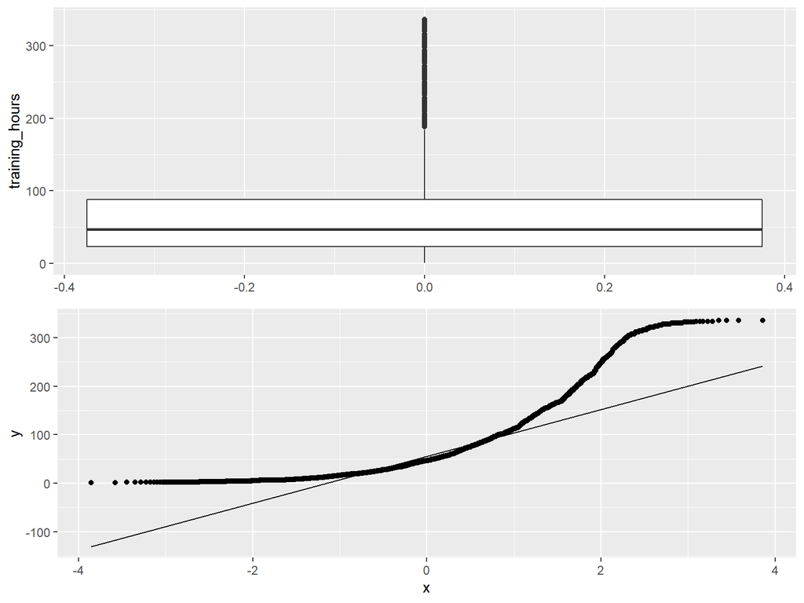

```r
t1 <- ggplot(job,aes(y=training_hours))+geom_boxplot()
t2 <- ggplot(job,aes(sample=training_hours))+geom_qq()+geom_qq_line()
grid.arrange(t1,t2)
```

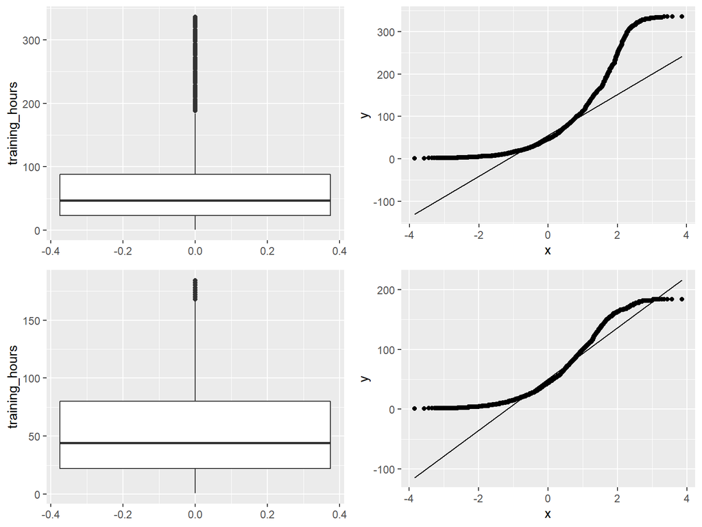

```r
o2 <- boxplot(job$training_hours,plot=F)$out
job <- job[-which(job$training_hours %in% o2),]
t3 <- ggplot(job,aes(y=training_hours))+geom_boxplot()
t4 <- ggplot(job,aes(sample=training_hours))+geom_qq()+geom_qq_line()
grid.arrange(t1,t2,t3,t4,nrow=2,ncol=2)
```

###Summary of data after Outlier Removal:

```r
summary(job)
```

```
##  city_development_index    gender         relevent_experience
##  Min.   :0.6240         Male  :7449   No experience :1016
##  1st Qu.:0.8040         Female: 745   Has Experience:7253
##  Median :0.9100         Other :  75
##  Mean   :0.8529
##  3rd Qu.:0.9200
##  Max.   :0.9490
##
##    enrolled_university education_level        major_discipline   experience
##  Not enrolled:7038     Graduate:5732   Arts           : 126    Min.   : 0.00
##  Part time   : 472     Masters :2304   Business Degree: 157    1st Qu.: 6.00
##  Full time   : 759     PhD     : 233   Humanities     : 358    Median :11.00
##                                        STEM           :7357    Mean   :11.78
##                                        Other          : 167    3rd Qu.:18.00
##                                        No Major       : 104    Max.   :21.00
##
##     company_size          company_type   last_new_job   training_hours
##  50-99    :1801   Early startup : 341   Min.   :0.000   Min.   :  1.0
##  100-500  :1680   Funded startup: 722   1st Qu.:1.000   1st Qu.: 22.0
##  10000+   :1370   NGO           : 328   Median :2.000   Median : 44.0
##  1000-4999: 881   Public        : 536   Mean   :2.379   Mean   : 55.2
##  <10      : 770   Private       :6276   3rd Qu.:4.000   3rd Qu.: 80.0
##  (Other)  : 930   Other         :  66   Max.   :5.000   Max.   :184.0
##  NA's     : 837
##                    target
##  Not looking to switch:6997
##  Looking for switch   :1272
##
##
##
##
##
```

### 1. Target data depicting how many employees are looking to switch.

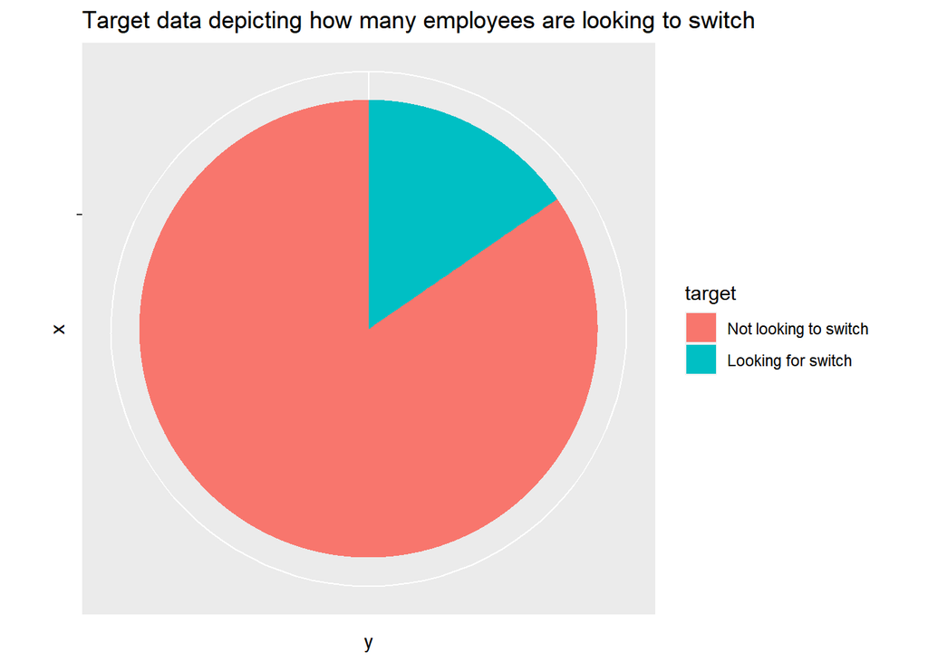

```r
ggplot(job, aes(x="", y="",fill=target)) +
  geom_bar(stat="identity", width=1) +
  coord_polar("y", start=0)+labs(title="Target data depicting how many employees are looking to switch")
```

### 2. Job switch classification based on Gender.

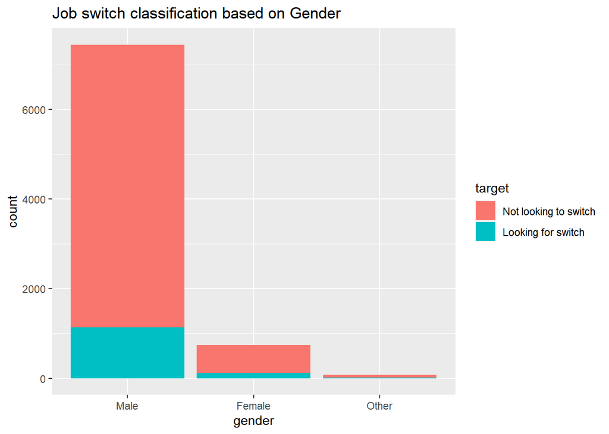

```r
ggplot(job,aes(x=gender,fill=target))+geom_bar()+labs(title = "Job switch classification based on Gender")
```

### 3. Job switch classification based on Relevent Experience.

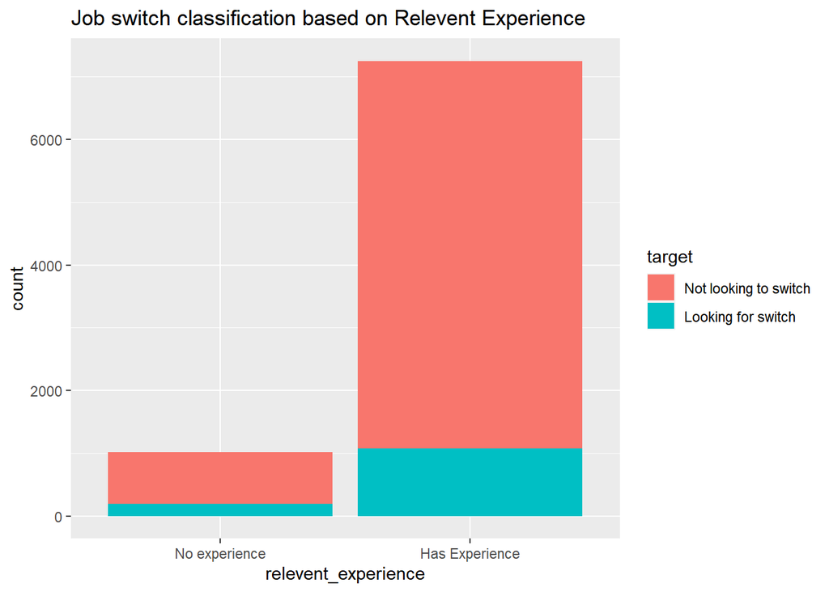

```r
ggplot(job,aes(x=relevent_experience,fill=target))+geom_bar()+labs(title="Job switch classification based on Relevent Experience")
```

### 4. Job switch Classification based on Education Level and current enrollment status of the employee.

### Not enrolled = full time job.

### Part time = part time enrolled with job.

### Full time = Full time enrolled along with job.

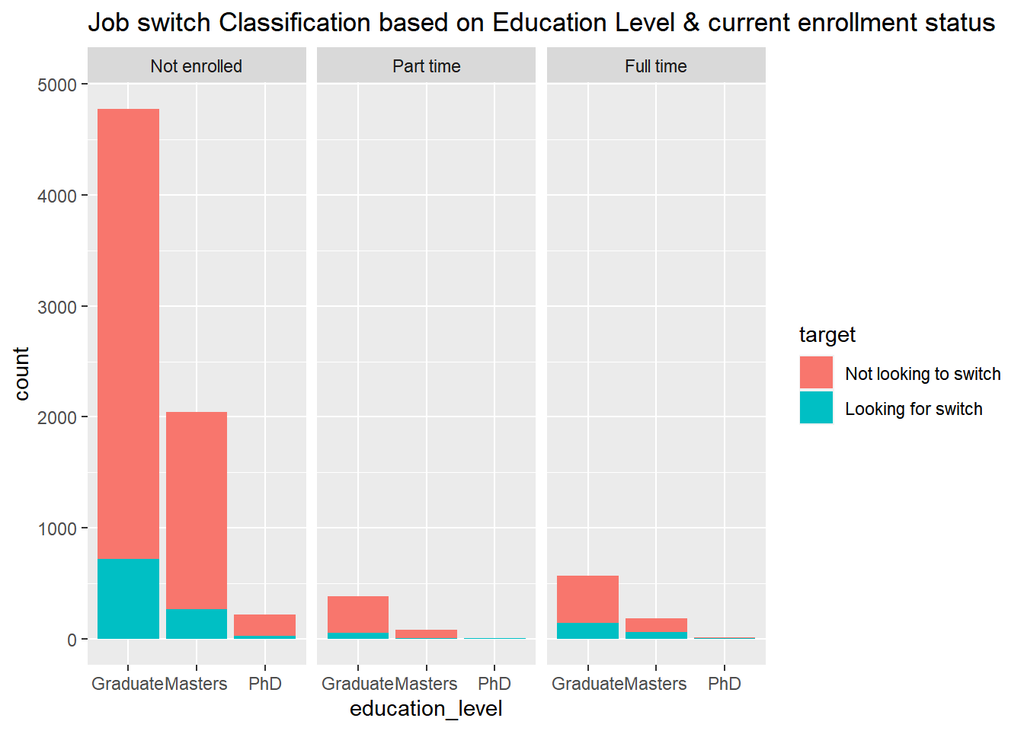

```r
ggplot(job,aes(x=education_level,fill=target))+facet_wrap(~enrolled_university)+geom_bar()+labs(title = "Job switch Classification based on Education Level & current enrollment status")
```

### 5. Job switch classification based on Study Major.

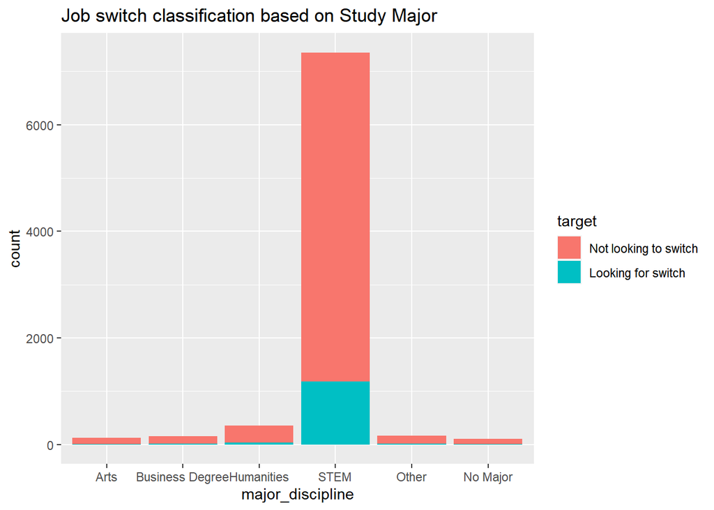

```r
ggplot(job,aes(x=major_discipline,fill=target))+geom_bar()+labs(title = "Job switch classification based on Study Major")
```

### 6. Job switch classification based on the size of company employee currently works in.

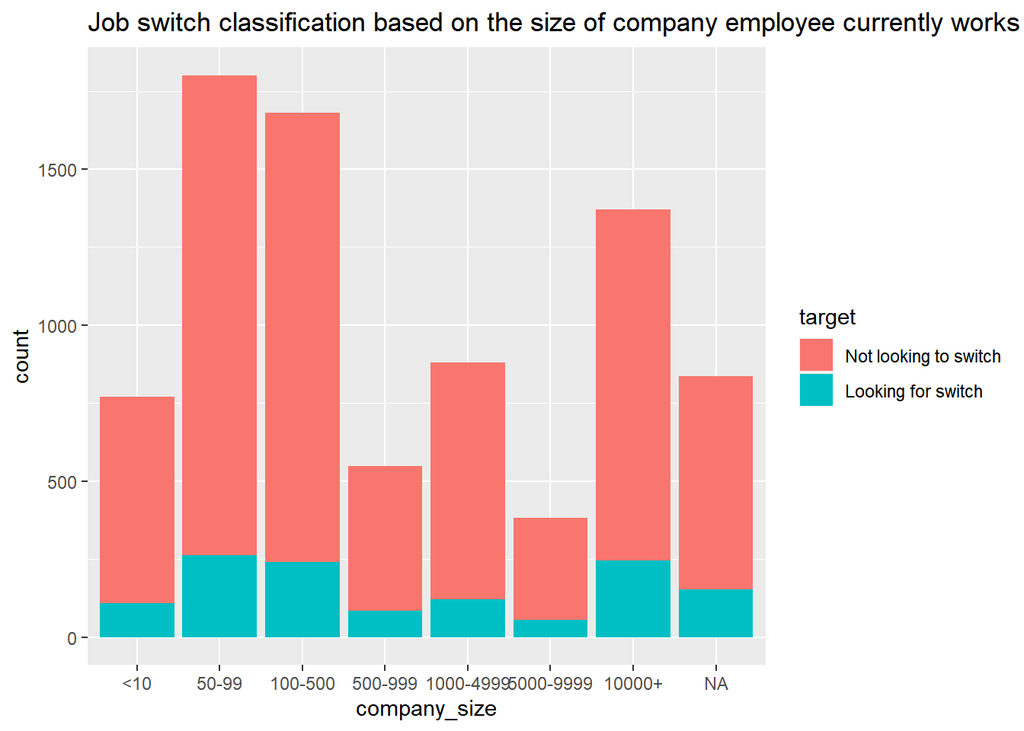

```r
ggplot(job,aes(x=company_size,fill=target))+geom_bar()+labs(title = "Job switch classification based on the size of company employee currently works")
```

### 7. Boxplot depicting the employees looking for job switch based on the city development index.

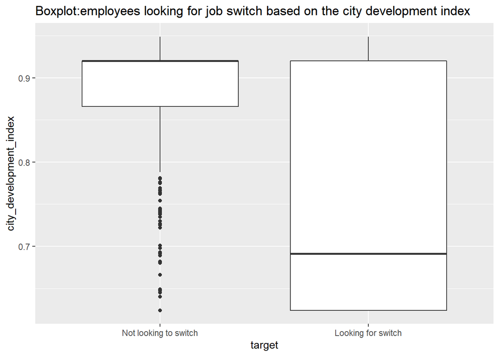

```r
ggplot(job,aes(x=target,y=city_development_index))+geom_boxplot()+labs(title = "Boxplot:employees looking for job switch based on the city development index")
```

### 8. Job switch classification based on the employee’s experience and the year they switched their last job.

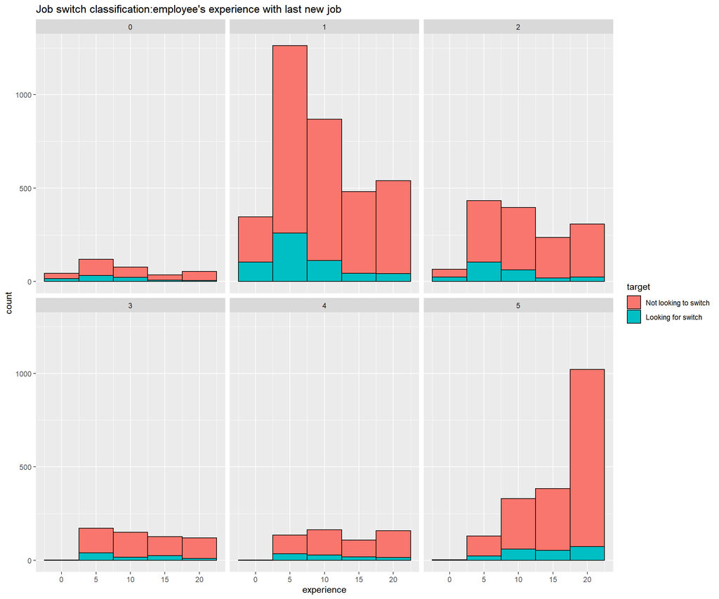

```r
ggplot(job,aes(x=experience,fill=target))+facet_wrap(~last_new_job)+geom_histogram(binwidth = 5,color='black')+labs(title = "Job switch classification:employee's experience with last new job")
```

### 9. Job switch classification based on last job change.

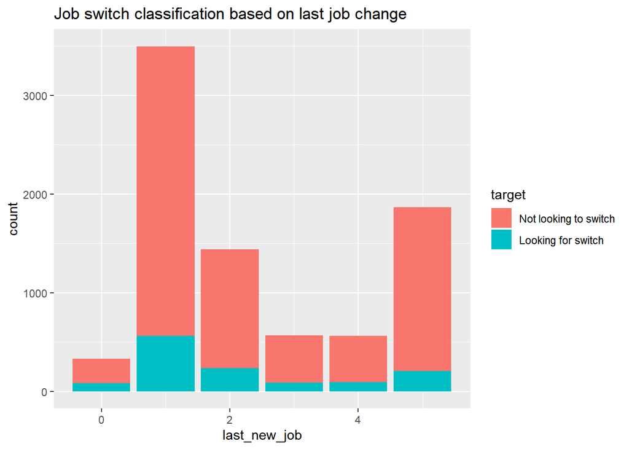

```r
ggplot(job,aes(x=last_new_job,fill=target))+geom_bar()+labs(title = "Job switch classification based on last job change")
```

### Decision Modeling:

### Model 1- Generalized Linear Model - Binomial Distribution

```r
glm.model <- glm(target ~ city_development_index + experience + last_new_job + training_hours, data=job, family ='binomial')
summary(glm.model)
```

```
##
## Call:
## glm(formula = target ~ city_development_index + experience +
##     last_new_job + training_hours, family = "binomial", data = job)
##
## Deviance Residuals:
##     Min       1Q   Median       3Q      Max
## -1.3034  -0.4691  -0.3963  -0.3322   2.5485
##
## Coefficients:
##                          Estimate Std. Error z value Pr(>|z|)
## (Intercept)             5.1337312  0.2160259  23.764  < 2e-16 ***
## city_development_index -7.8374566  0.2768087 -28.314  < 2e-16 ***
## experience             -0.0430185  0.0062743  -6.856 7.07e-12 ***
## last_new_job            0.0545072  0.0228443   2.386   0.0170 *
## training_hours         -0.0015423  0.0008033  -1.920   0.0549 .
## ---
## Signif. codes:  0 '***' 0.001 '**' 0.01 '*' 0.05 '.' 0.1 ' ' 1
##
## (Dispersion parameter for binomial family taken to be 1)
##
##     Null deviance: 7099.6  on 8268  degrees of freedom
## Residual deviance: 5958.6  on 8264  degrees of freedom
## AIC: 5968.6
##
## Number of Fisher Scoring iterations: 5
```

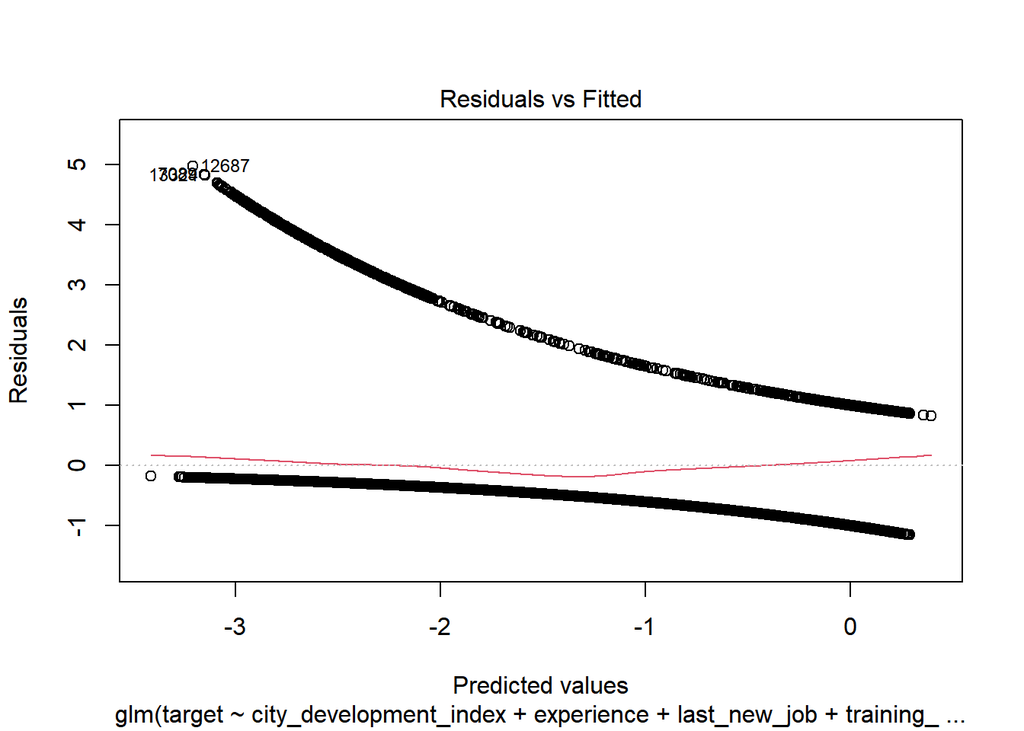

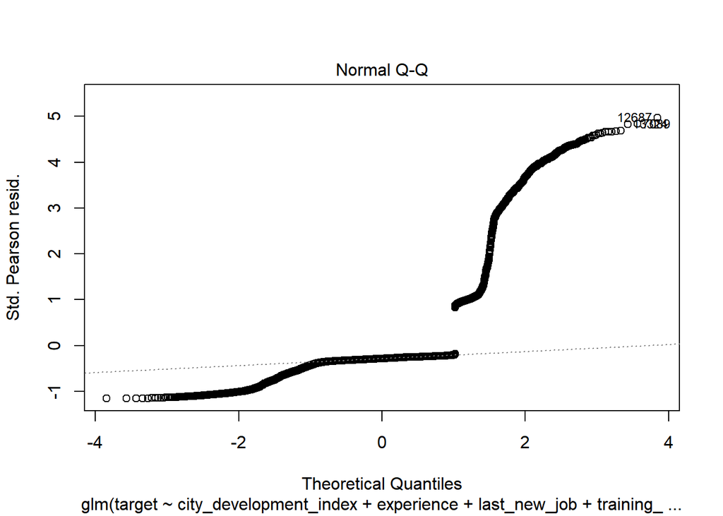

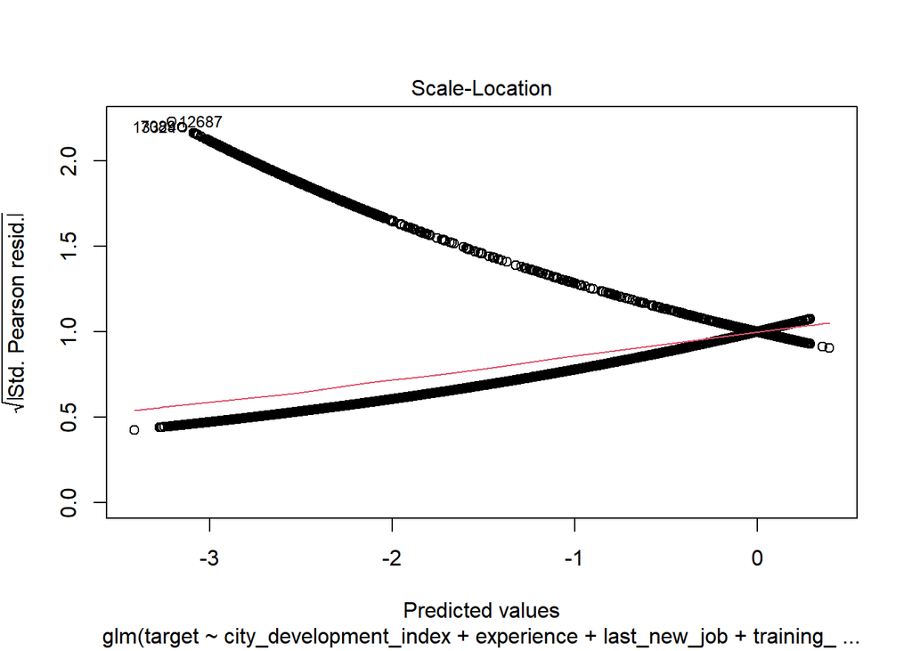

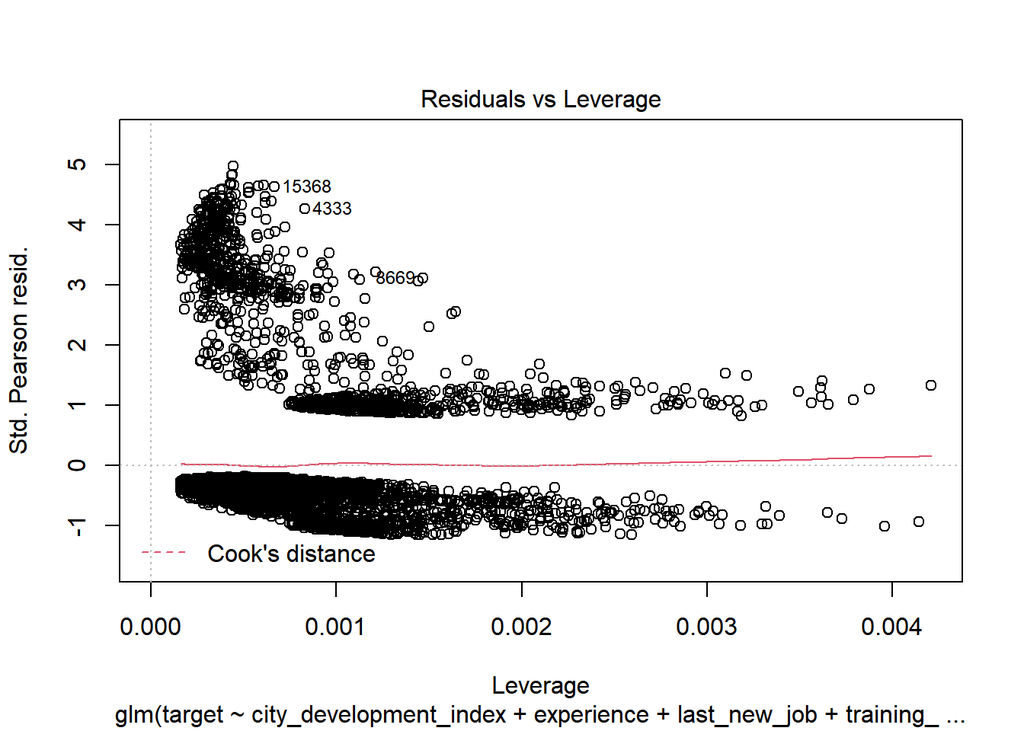

```r
plot(glm.model)
```

#### Cross-validation of GLM to determine the accuracy of the model.

```r
CVbinary(glm.model)
```

```
##
## Fold:  9 8 1 2 10 5 7 3 6 4
## Internal estimate of accuracy = 0.858
## Cross-validation estimate of accuracy = 0.859
```

###The significance of the model is stated below:

```r
1 - pchisq(7099.6-5958.6,8268-8264)
```

```
## [1] 0
```

### Model 2 - Big vs Small Model

#### Big Model:

### For the Big model we will consider the same number of independent variables as we did for our Generalized Linear Model.

```r
glm.big <- glm(target~city_development_index+experience+last_new_job+training_hours,data = job, family = "binomial")
summary(glm.big)
```

```
##
## Call:
## glm(formula = target ~ city_development_index + experience +
##     last_new_job + training_hours, family = "binomial", data = job)
##
## Deviance Residuals:
##     Min       1Q   Median       3Q      Max
## -1.3034  -0.4691  -0.3963  -0.3322   2.5485
##
## Coefficients:
##                          Estimate Std. Error z value Pr(>|z|)
## (Intercept)             5.1337312  0.2160259  23.764  < 2e-16 ***
## city_development_index -7.8374566  0.2768087 -28.314  < 2e-16 ***
## experience             -0.0430185  0.0062743  -6.856 7.07e-12 ***
## last_new_job            0.0545072  0.0228443   2.386   0.0170 *
## training_hours         -0.0015423  0.0008033  -1.920   0.0549 .
## ---
## Signif. codes:  0 '***' 0.001 '**' 0.01 '*' 0.05 '.' 0.1 ' ' 1
##
## (Dispersion parameter for binomial family taken to be 1)
##
##     Null deviance: 7099.6  on 8268  degrees of freedom
## Residual deviance: 5958.6  on 8264  degrees of freedom
## AIC: 5968.6
##
## Number of Fisher Scoring iterations: 5
```

#### Small Model:

### Since we can see a greater z value for city_development_index and experience. Let’s consider these two variables for our small model. Hence, eliminating last_new_job and training_hours from our consideration.

```r
glm.small <- glm(target~city_development_index+experience,data = job,family = "binomial")
summary(glm.small)
```

```
##
## Call:
## glm(formula = target ~ city_development_index + experience, family = "binomial",
##     data = job)
##
## Deviance Residuals:
##     Min       1Q   Median       3Q      Max
## -1.2698  -0.4649  -0.3965  -0.3314   2.4781
##
## Coefficients:
##                         Estimate Std. Error z value Pr(>|z|)
## (Intercept)             5.086422   0.209593  24.268  < 2e-16 ***
## city_development_index -7.807475   0.276269 -28.260  < 2e-16 ***
## experience             -0.037051   0.005717  -6.481 9.12e-11 ***
## ---
## Signif. codes:  0 '***' 0.001 '**' 0.01 '*' 0.05 '.' 0.1 ' ' 1
##
## (Dispersion parameter for binomial family taken to be 1)
##
##     Null deviance: 7099.6  on 8268  degrees of freedom
## Residual deviance: 5968.0  on 8266  degrees of freedom
## AIC: 5974
##
## Number of Fisher Scoring iterations: 5
```

### Plots:

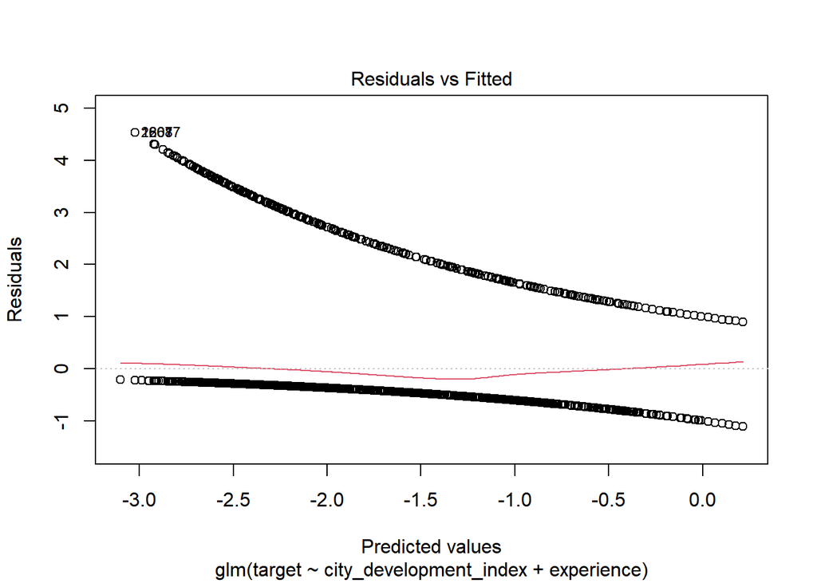

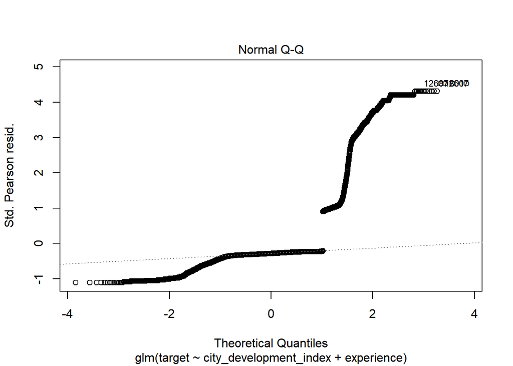

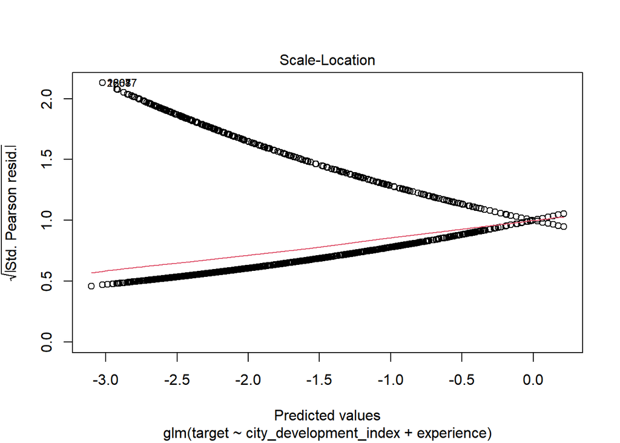

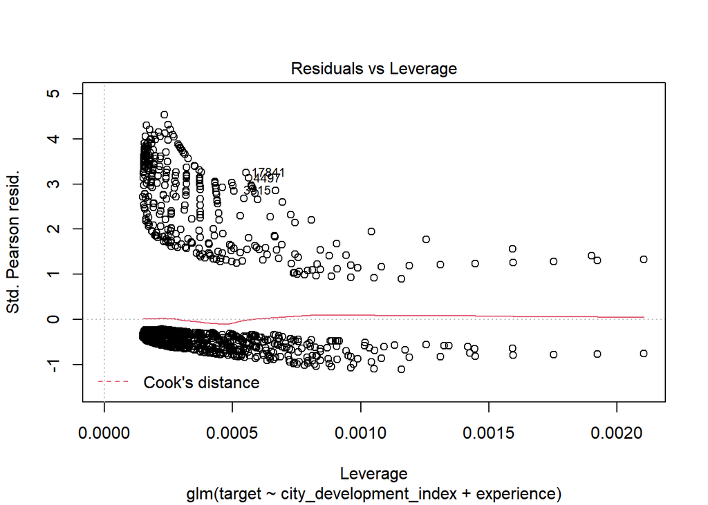

```r
plot(glm.small)
```

### Let’s run the anova function to have a look at the Deviance for the models:

```r
anova(glm.small,glm.big, test = 'Chisq')
```

|  | Resid. Df | Resid. Dev | Df | Deviance | Pr(>Chi) |
| --- | --- | --- | --- | --- | --- |
| 1 | 8266 | 5968.013 | NA | NA | NA |
| 2 | 8264 | 5958.637 | 2 | 9.376262 | 0.00920387 |

### F-statistic for both big and small models:

```r
glm.big.sse <- deviance(glm.big)
glm.big.df <- df.residual(glm.big)
glm.small.sse <- deviance(glm.small)
glm.small.df <- df.residual(glm.small)
glm.mse <- (glm.small.sse-glm.big.sse)/(glm.small.df-glm.big.df)
glm.big.mse <- glm.big.sse/glm.big.df
glm.fratio <- glm.mse/glm.big.mse
```

### The F-statistic ratio of the big vs small model is 6.501943

```r
glm.pval <- 1-pf(glm.fratio,glm.small.df-glm.big.df,glm.big.df)
```

### Let’s run the cross validation on both the big and small models to get relevant accuracy of both the models:

```r
CVbinary(glm.big)
```

```
##
## Fold:  8 1 2 3 4 7 9 10 6 5
## Internal estimate of accuracy = 0.858
## Cross-validation estimate of accuracy = 0.859
```

```r
CVbinary(glm.small)
```

```
##
## Fold:  1 6 7 4 8 9 5 3 10 2
## Internal estimate of accuracy = 0.859
## Cross-validation estimate of accuracy = 0.86
```

###The accuracy of both the model is similar. Based on this observation we can conclude that the presence of last_new_job and training_hours does not impact the accuracy of the model by much.